# Used-habitat calibration plots

Marie Gilbertson

2025-03-03

# Introduction

In this report, I’ll demonstrate adapting the approach described by [Fieberg et al. 2017](https://doi.org/10.1111/ecog.03123) for validating step-selection models: used-habitat calibration (UHC) plots.

Commenting is relatively minimal for some functions. This is done to encourage users to refer to the [original code](http://doi.org/10.13020/D6T590) published by Fieberg et al. Their documentation is excellent. **Both the Fieberg et al. publication and code should be reviewed prior to using the code in this report.**

In the manuscript associated with this report, we fit individual-level integrated step selection functions (iSSFs) for thousands of trajectories. Replicating this for an RMarkdown report is not practical, so I’ll demonstrate our approach at a smaller scale.

We’ll start by loading the packages we’ll need. I also always set my seed as standard practice (this makes randomization reproducible).

```r
##### Clear Environment #####
remove(list=ls())


#### set seed ####
set.seed(1654)


#### load libraries ####
library(plyr)
library(dplyr)
library(amt)
library(ggplot2)
library(tidyverse)
library(lubridate)
library(sf)
```

## Load data and functions

We’ll load some data that I have specifically prepared for this demonstration. This is movement data from one individual in the same season, but two different years. One has randomly been assigned the “training” data, and the other the “testing” data.

The data has been prepared for iSSF fitting, meaning that relevant covariates have been extracted (see the iSSF_analysis report) and predictors have been scaled and centered. In addition, I have verified that the same land use classifications are present for both datasets, with identical levels. We can load and preview these two datasets.

```r
uhc.demo.dat <- get(load("../Project_data/UHC_demo_data.Rdata"))
train <- uhc.demo.dat$train
test <- uhc.demo.dat$test

print(head(train), width = Inf)
```

```
## # A tibble: 6 × 19
##       x1_     x2_     y1_     y2_   sl_    ta_ t1_
## *   <dbl>   <dbl>   <dbl>   <dbl> <dbl>  <dbl> <dttm>
## 1 480893. 480987. 288966. 288546. 429.  NA     2018-05-01 01:00:30
## 2 480893. 480964. 288966. 289144. 192.   2.54  2018-05-01 01:00:30
## 3 480893. 480861. 288966. 289237. 273.   3.04  2018-05-01 01:00:30
## 4 480893. 480892. 288966. 288951.  14.3 -0.342 2018-05-01 01:00:30
## 5 480893. 481003. 288966. 289067. 150.   2.10  2018-05-01 01:00:30
## 6 480893. 480622. 288966. 289024. 277.  -2.00  2018-05-01 01:00:30
##   t2_                 dt_     step_id_ case_ flu_end4   ndvi_end eastness
## * <dttm>              <drtn>     <int> <lgl> <fct>         <dbl>    <dbl>
## 1 2018-05-01 05:00:30 4 hours        1 TRUE  hay           0.467   0.906
## 2 2018-05-01 05:00:30 4 hours        1 FALSE hay           0.496  -0.821
## 3 2018-05-01 05:00:30 4 hours        1 FALSE grass.past    0.496  -0.925
## 4 2018-05-01 05:00:30 4 hours        1 FALSE grass.past    0.447   0.862
## 5 2018-05-01 05:00:30 4 hours        1 FALSE grass.past    0.447  -0.684
## 6 2018-05-01 05:00:30 4 hours        1 FALSE soybean       0.430   0.0764
##   northness fe.dist log_sl_ cos.ang log_fe.dist
## *     <dbl>   <dbl>   <dbl>   <dbl>       <dbl>
## 1     0.424     0      6.06  NA          -2.50
## 2     0.570    67.1    5.26  -1.33        0.309
## 3    -0.379    60      5.61  -1.57        0.281
## 4     0.508    67.1    2.66   1.18        0.309
## 5    -0.730   120      5.01  -0.875       0.456
## 6     0.997   150      5.62  -0.750       0.513
```

```r
print(head(test), width = Inf)
```

```
## # A tibble: 6 × 19
##       x1_     x2_     y1_     y2_    sl_    ta_ t1_
## *   <dbl>   <dbl>   <dbl>   <dbl>  <dbl>  <dbl> <dttm>
## 1 480870. 481017. 288929. 288765. 220.   NA     2017-05-01 03:00:29
## 2 480870. 481090. 288929. 288806. 252.    0.328 2017-05-01 03:00:29
## 3 480870. 480878. 288929. 288934.   8.74  1.45  2017-05-01 03:00:29
## 4 480870. 481211. 288929. 288836. 353.    0.573 2017-05-01 03:00:29
## 5 480870. 481220. 288929. 289088. 384.    1.27  2017-05-01 03:00:29
## 6 480870. 480778. 288929. 288930.  92.6  -2.31  2017-05-01 03:00:29
##   t2_                 dt_         step_id_ case_ flu_end4          ndvi_end
## * <dttm>              <drtn>         <int> <lgl> <fct>                <dbl>
## 1 2017-05-01 07:00:47 4.005 hours        1 TRUE  central.hardwoods    0.593
## 2 2017-05-01 07:00:47 4.005 hours        1 FALSE grass.past           0.683
## 3 2017-05-01 07:00:47 4.005 hours        1 FALSE grass.past           0.540
## 4 2017-05-01 07:00:47 4.005 hours        1 FALSE central.hardwoods    0.683
## 5 2017-05-01 07:00:47 4.005 hours        1 FALSE central.hardwoods    0.620
## 6 2017-05-01 07:00:47 4.005 hours        1 FALSE hay                  0.486
##   eastness northness fe.dist log_sl_  cos.ang log_fe.dist
## *    <dbl>     <dbl>   <dbl>   <dbl>    <dbl>       <dbl>
## 1   0.799      0.602    84.9    5.40 NA             0.369
## 2  -0.839     -0.545     0      5.53  1.19         -2.50
## 3   0.769      0.639    42.4    2.17  0.00663       0.194
## 4  -0.994     -0.106    42.4    5.87  1.04          0.194
## 5  -0.864     -0.504    67.1    5.95  0.267         0.309
## 6  -0.0608     0.998   108.     4.53 -1.11          0.430
```

Next, we’ll load some functions. These functions are based on corresponding functions published by Fieberg et al. (see link above). **Review their original code for more information.** The uchsimstrat() function has just been slightly modified; uhc_dens() is identical to the original code.

```r
## From Fieberg et al:
# uhcsimstrat "samples, randomly, locations from stratified test data.
#
# This function samples, randomly, locations from stratified
# test data and returns an array of dimension nsims x nused_test x p (where p
# is the number of predictors to be validated) "

uhc_sim.strat <- function (nsims, xmat, stratum, fit_ssf, z) {
  xmat <- xmat[,-1] #remove intercept
  ustrat <- unique(stratum) # unique strata
  nstrat <- length(ustrat) # number of strata

  # array to store chosen x's for each simulation
  x_sim_choice <- array(NA, dim = c(nsims, nstrat, ncol(z)))
  # new beta^ for each simulation
  beta.hats <- MASS::mvrnorm(nsims, coef(fit_ssf), fit_ssf$model$var)
  ntot.test <- nrow(xmat) # total number of test observations

  dimxmat <- ncol(xmat)
  tempdat <- as.data.frame(cbind(1:nrow(xmat), stratum, z))
  names(tempdat)[1] <- "inds"
  for (i in 1:nsims) {
    # Use new beta^ vector to generate predicted values for test data
    lp.hat.s <- as.matrix(xmat) %*% beta.hats[i, ]
    tempdat$wx.s <- exp(lp.hat.s)
    tempdat.g <- tempdat %>% group_by(stratum)
    x_sim_choice[i, , ] <- z[sample_n(tempdat.g, 1, weight = wx.s)$inds,] # choices
  }
  return(x_sim_choice)
}


# From Fieberg et al.:
# uhcdenscalc "calculates kernal density estimates to create UHC plots.
#
# calculates density estimates for the environmental
# characteristics associated with the observed and available locations in the
# test data and also those associated with the randomly chosen locations
# generated by the uhcsim() or uhcsimstrat() functions."
uhc_dens <- function (rand_sims, dat, avail, gridsize = 500) {
  # Density plot of x for each simulated data set & also for the test data set
  rand_sims <- as.matrix(rand_sims)
  dat <- as.matrix(dat)
  avail <- as.matrix(avail)
  alldat <- c(rand_sims, dat, avail) # combine data to get reasonable axis limits
  range.x <- c(min(alldat), max(alldat)) # to get reasonable axis limits
  nsims <- nrow(rand_sims)

  # to hold density estimates fU^(z) for all nsims datasets
  densrand <- matrix(NA, nsims, gridsize)
  # observed data density, fu(z)
  densdat <- KernSmooth::bkde(as.vector(dat), range.x = range.x,
                              gridsize = gridsize)
  for (i in 1:nsims) {
    temp <- KernSmooth::bkde(rand_sims[i, ], range.x = range.x,
                             gridsize = gridsize)
    densrand[i, ] <- temp$y
  }
  # density of available points
  densavail <- KernSmooth::bkde(as.vector(avail), range.x = range.x,
                                gridsize = gridsize)
  out <- list(densdat = densdat, densrand = densrand, densavail = densavail)
  return(out)
}
```

## Training model

We’ll use our training data, fitting our candidate iSSF model to that data. I’m demonstrating with a model formula, as this approach can streamline scaling up to testing multiple candidate iSSFs.

```r
### fit model(s) to training data
mod.formula <- as.formula(paste(
    "case_ ~
    log_sl_ + cos.ang +
    poly(eastness, 2, raw = TRUE) + northness +
    log_fe.dist +
    flu_end4*ndvi_end + strata(step_id_)",
    collapse = " "
  ))


training.mod <- train %>% fit_issf(mod.formula, model = T)
```

## Generate simulation envelope

Next, we’ll run 100 simulations using our fitted model (trained with our training data) and our test data. This will allow us to generate the 95% simulation envelope representing the predicted distribution of habitat covariates at used test locations. **Check out Figure 3 in Fieberg et al. 2018 for a lovely overview of how this process works.**

In this first chunk, we’re running our simulations:

```r
## We can't have any rows in our test data with missing data
## I have more columns than the covariates we care about, so I only want to exclude rows where our specific covariate data is missing
na.cols <- which(apply(test[,c("sl_", "ta_", "flu_end4", "ndvi_end", "eastness", "northness", "fe.dist")], 2,
                       function(x) sum(is.na(x))) !=0)
na.dat <- test[,c("sl_", "ta_", "flu_end4", "ndvi_end", "eastness", "northness", "fe.dist")][, na.cols]

na.rows <- unique(unlist(apply(na.dat, 2, function(x) which(is.na(x)))))
mdat.test <- test[-c(na.rows),]

## Model matrix for our test data, based on our model formula from before
design.mat.test.full <- model.matrix(mod.formula, data=mdat.test)
## Move all the strata elements to their own design matrix
strata.mat <- design.mat.test.full[,grepl("strata", colnames(design.mat.test.full))]
design.mat.test.full <- design.mat.test.full[,!grepl("strata", colnames(design.mat.test.full))]

## Model matrix of just the habitat covariates
z.col <- colnames(design.mat.test.full)
z.col <- z.col[!grepl("Intercept|sl_|ang", z.col)]
z <- model.matrix(mod.formula,
                  data = mdat.test)
z <- z[,which(colnames(z) %in% z.col)]

## Create a vector of the different strata
uniq.strat <- sub(".*=", "", colnames(strata.mat))
reps.strat <- colSums(strata.mat)
strata.vec <- rep(uniq.strat, reps.strat)
strata.vec <- as.numeric(c(rep("1", nrow(z) - length(strata.vec)), strata.vec))

## Run the simulations
xchoice.full <- NA
xchoice.full <- uhc_sim.strat(nsims = 100,
                            xmat = design.mat.test.full,
                            stratum = strata.vec,
                            fit_ssf = training.mod,
                            z = z)
```

## Review observed versus predicted distributions

Our simulations fundamentally give us the predicted distributions of our habitat covariates for used test data points. We now need to compare that to the observed distribution for that same data. A “well calibrated” model should have the observed distribution falling within the predicted distribution. Furthermore, we can compare the distribution for available points within the test dataset. If the observed versus available distributions are quite different, this can be suggestive of that habitat covariate being an important predictor.

For the purpose of this demonstration, I will just show this process with one of our habitat covariates: log-transformed distance to the nearest forest edge (“log_fe.dist”). We’ll start by generating the kernel density estimate from our simulated data, and extract the 95% simulation envelope.

```r
variables <- colnames(z)
v <- which(variables=="log_fe.dist")

## kernel density estimate from simulated data
denshats.full <- uhc_dens(rand_sims=xchoice.full[,,v],
                          dat=z[mdat.test$case_,v],
                          avail=z[!mdat.test$case_,v], gridsize = 2000)


## x-values
xs <- denshats.full$densdat$x

## y-values for observed and available points
obs.y <- denshats.full$densdat$y
avl.y <- denshats.full$densavail$y

## lower quantile of the simulation envelope
low.s <- apply(denshats.full$densrand, 2, quantile, prob = 0.025, na.rm = TRUE)
## upper quantile of the simulation envelope
up.s <- apply(denshats.full$densrand, 2, quantile, prob = 0.975, na.rm = TRUE)
```

When scaling this process up to many individuals, we need a quick way to examine how much of the observed distribution falls within the simulation envelope. We addressed this challenge by converting the simulation envelope into a polygon object, and the observed and available distributions into linestring objects. We could then calculate the proportion of each linestring that fell within the simulation envelope polygon.

```r
pol <- st_sfc(st_polygon(list(cbind(c(xs, rev(xs), xs[1]),c(up.s, rev(low.s), up.s[1])))))
obs.line <- st_sfc(st_linestring(matrix(c(xs, obs.y), ncol = 2)))
avl.line <- st_sfc(st_linestring(matrix(c(xs, avl.y), ncol = 2)))


obs.o.length <- st_length(obs.line)
avl.o.length <- st_length(avl.line)

obs.c.line <- st_intersection(obs.line, pol)
avl.c.line <- st_intersection(avl.line, pol)


obs.c.length <- st_length(obs.c.line)
avl.c.length <- st_length(avl.c.line)

## dealing with any "points" in the line data for plotting purposes
if(any(unlist(lapply(obs.c.line[[1]], function(x) any(class(x)=="POINT"))))){
  obs.c.line <- obs.c.line[[1]][-which(unlist(lapply(obs.c.line[[1]], function(x) any(class(x)=="POINT"))))]
  obs.c.line <- st_sfc(obs.c.line)
}
if(any(unlist(lapply(avl.c.line[[1]], function(x) any(class(x)=="POINT"))))){
  avl.c.line <- avl.c.line[[1]][-which(unlist(lapply(avl.c.line[[1]], function(x) any(class(x)=="POINT"))))]
  avl.c.line <- st_sfc(avl.c.line)
}

## proportion of observed and available within simulation envelope
obs.prop <- obs.c.length/obs.o.length
avl.prop <- avl.c.length/avl.o.length

print(c(obs.prop, avl.prop))
```

```
## [1] 0.9494449 0.2308145
```

Finally, we can plot all of this to better see how everything fits together.

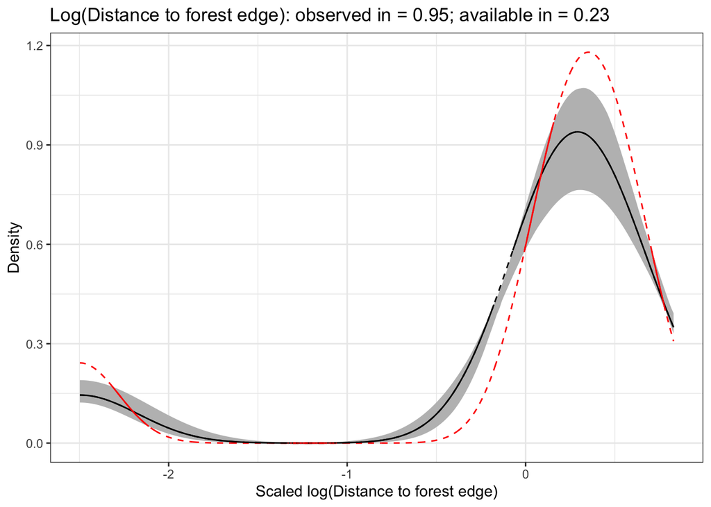

```r
## data frames for plotting
pol.df <- data.frame(st_coordinates(pol))
obs.line.df <- data.frame(st_coordinates(obs.line))
avl.line.df <- data.frame(st_coordinates(avl.line))
obs.c.line.df <- data.frame(st_coordinates(obs.c.line))
avl.c.line.df <- data.frame(st_coordinates(avl.c.line))


ggplot() +
  geom_polygon(data = pol.df, aes(x = X, y = Y), fill = "grey") +
  geom_path(data = obs.line.df, aes(x = X, y = Y), linetype = "dashed") +
  geom_path(data = avl.line.df, aes(x = X, y = Y), color = "red", linetype = "dashed") +
  geom_path(data = obs.c.line.df, aes(x = X, y = Y, group = L1)) + geom_path(data = avl.c.line.df, aes(x = X, y = Y, group = L1), color = "red") +
  ggtitle(paste0("Log(Distance to forest edge)", ": ", "observed in = ", round(obs.prop, 2), "; available in = ", round(avl.prop, 2))) +
  theme_bw() +
  xlab("Scaled log(Distance to forest edge)") + ylab("Density")
```

## Conclusion

This report is just using training and testing data for one individual, and examining only one habitat covariate from our model. But we can readily scale this up using for-loops or parallelization. Key steps for scaling up include using model formulas, so these can readily be changed to test different models, and calculating the proportions of observed and available distributions within simulation envelopes. This latter step allows the user to review these proportions across many individuals to determine if a covariate is consistently well-calibrated.